# p8130_Final_Project

## Data exploration

**Q: do we need to convert other variables to per 1,000 population? like docs, beds, etc.**

```r
cdi = read_csv("cdi.csv") %>%
  janitor::clean_names() %>%
  mutate(crm_1000 = 1000*(crimes/pop),
         # convert region to factors and recoded them accordingly
         region = factor(region, levels = 1:4,
                    labels = c("northeast", "north central", "south", "west"))) %>% view()
```

### Descriptive statistics of all varaibles

```r
cdi_descriptive = cdi %>% select(-c(id,cty,state,region))

# Global
skimr::skim(cdi_descriptive) %>%
  select(-c("skim_type","complete_rate")) %>%
  knitr::kable(
    col.names = c("variable", "n_missing", "mean","sd","min","Q25","median","Q75","max","histogram"),
    caption = "Global Summary", digits = 2)
```

Global Summary

| variable | n_missing | mean | sd | min | Q25 | median | Q75 | max | histogram |
| --- | --- | --- | --- | --- | --- | --- | --- | --- | --- |
| area | 0 | 1041.41 | 1549.92 | 15.0 | 451.25 | 656.50 | 946.75 | 20062.00 | ▇▁▁▁▁ |
| pop | 0 | 393010.92 | 601987.02 | 100043.0 | 139027.25 | 217280.50 | 436064.50 | 8863164.00 | ▇▁▁▁▁ |
| pop18 | 0 | 28.57 | 4.19 | 16.4 | 26.20 | 28.10 | 30.02 | 49.70 | ▁▇▃▁▁ |
| pop65 | 0 | 12.17 | 3.99 | 3.0 | 9.88 | 11.75 | 13.62 | 33.80 | ▂▇▁▁▁ |
| docs | 0 | 988.00 | 1789.75 | 39.0 | 182.75 | 401.00 | 1036.00 | 23677.00 | ▇▁▁▁▁ |
| beds | 0 | 1458.63 | 2289.13 | 92.0 | 390.75 | 755.00 | 1575.75 | 27700.00 | ▇▁▁▁▁ |
| crimes | 0 | 27111.62 | 58237.51 | 563.0 | 6219.50 | 11820.50 | 26279.50 | 688936.00 | ▇▁▁▁▁ |
| hsgrad | 0 | 77.56 | 7.02 | 46.6 | 73.88 | 77.70 | 82.40 | 92.90 | ▁▁▃▇▃ |
| bagrad | 0 | 21.08 | 7.65 | 8.1 | 15.28 | 19.70 | 25.33 | 52.30 | ▆▇▃▁▁ |
| poverty | 0 | 8.72 | 4.66 | 1.4 | 5.30 | 7.90 | 10.90 | 36.30 | ▇▆▁▁▁ |
| unemp | 0 | 6.60 | 2.34 | 2.2 | 5.10 | 6.20 | 7.50 | 21.30 | ▇▇▁▁▁ |
| pcincome | 0 | 18561.48 | 4059.19 | 8899.0 | 16118.25 | 17759.00 | 20270.00 | 37541.00 | ▁▇▂▁▁ |
| totalinc | 0 | 7869.27 | 12884.32 | 1141.0 | 2311.00 | 3857.00 | 8654.25 | 184230.00 | ▇▁▁▁▁ |
| crm_1000 | 0 | 57.29 | 27.33 | 4.6 | 38.10 | 52.43 | 72.60 | 295.99 | ▇▅▁▁▁ |

Q: 1. do we need to group them by state or county? group by gounty gives 5000+ rows though… 2. do we need box plot still? 3. again, transfer some variables to “per pop” / “per 1000 pop” ?

### Descriptive analysis

We can use the box plot/ or histogram to check for normality. But I forgot when do we need normality…isn’t it for residual??

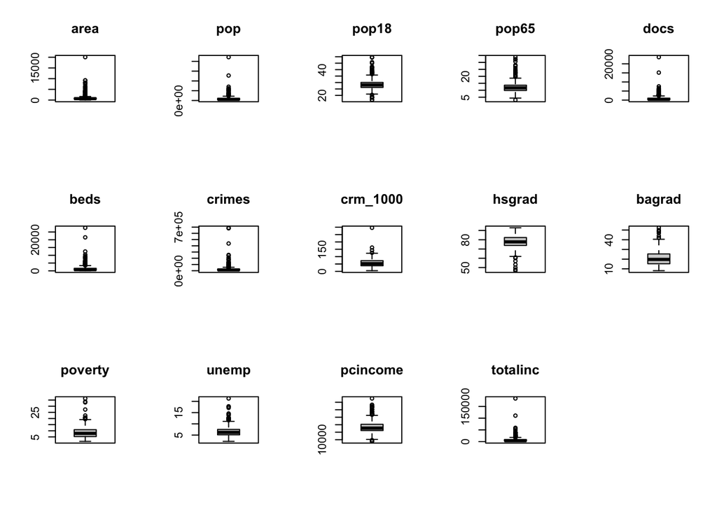

```r
par(mfrow=c(3,5))

boxplot(cdi$area,  main = "area")
boxplot(cdi$pop, main = "pop")
boxplot(cdi$pop18, main = "pop18")
boxplot(cdi$pop65, main = "pop65")

boxplot(cdi$docs, main = "docs")
boxplot(cdi$beds, main = "beds")
boxplot(cdi$crimes, main = "crimes")
boxplot(cdi$crm_1000,  main = "crm_1000")

boxplot(cdi$hsgrad, main = "hsgrad")
boxplot(cdi$bagrad, main = "bagrad")
boxplot(cdi$poverty, main = "poverty")
boxplot(cdi$unemp,main = "unemp")
boxplot(cdi$pcincome, main = "pcincome")
boxplot(cdi$totalinc, main = "totalinc")
```

### Correlation

#### Pairwise relationship

- This gives us an idea of the correlation between each variable, but my old project build whole model first then assessed the correlation. Need Discussion!

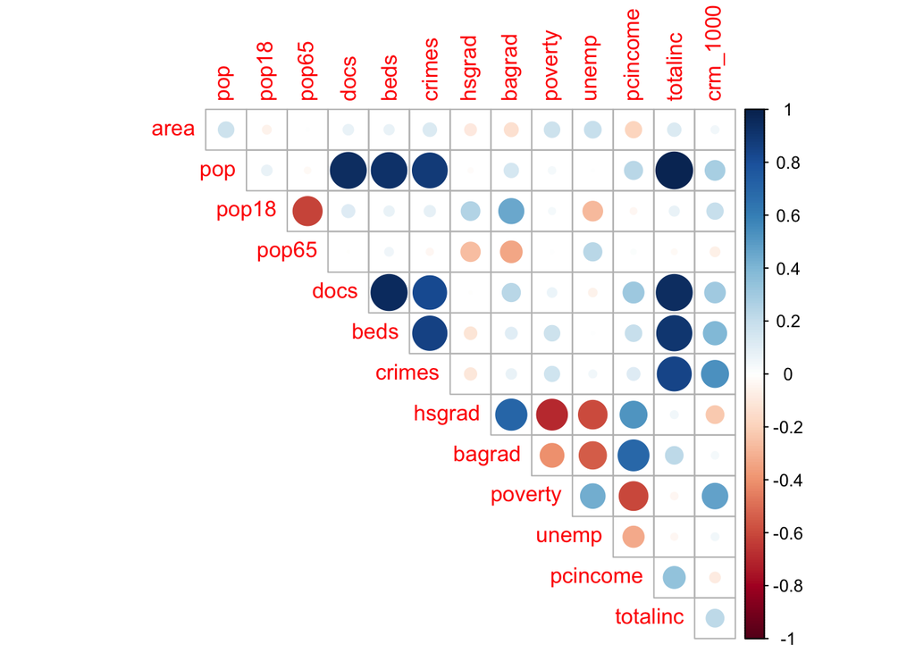

```r
library(corrplot)
corrplot(cor(cdi_descriptive), type = "upper", diag = FALSE)
```

- Here is the correlation with pairs function. More specific than the heat map above. We can observe the correlation bewteen all the terms here

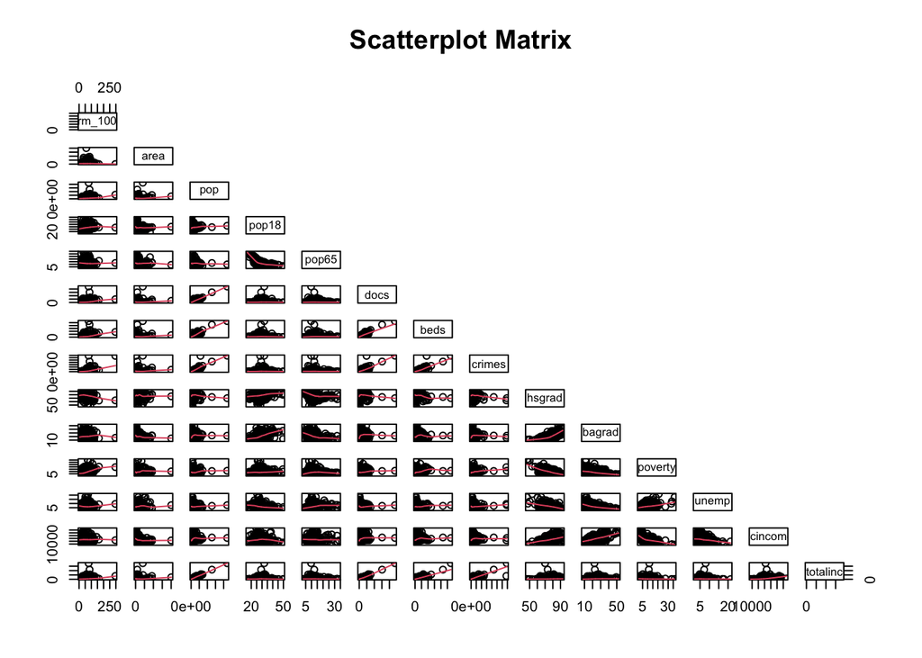

```r
pairs(crm_1000 ~.,data=cdi_descriptive, panel = panel.smooth, upper.panel = NULL, main = "Scatterplot Matrix")
```

### Distribution of outcome

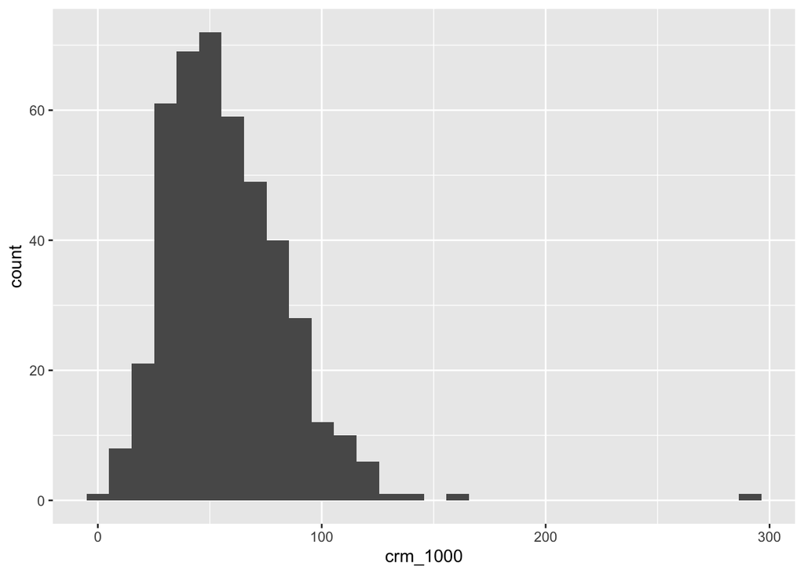

```r
cdi %>%
  ggplot(aes(x = crm_1000)) +
  geom_histogram()
```

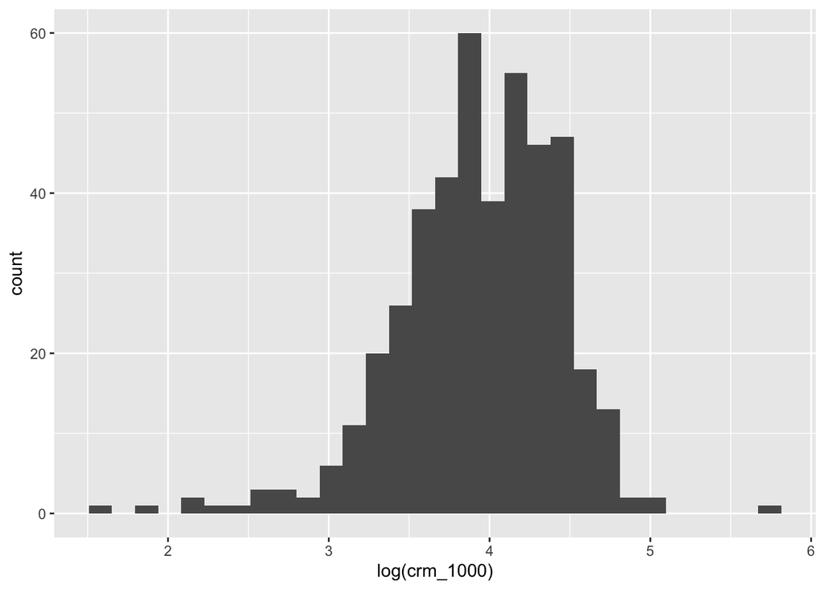

```r
# log transfor the outcome
cdi %>%
  ggplot(aes(x = log(crm_1000))) +
  geom_histogram()
```

do we look at the distribution of outcome like this and transform them here? check again

### States with unusual rates

group by state

```r
cdi_by_state = cdi %>% group_by(state) %>%
  summarise(state_pop = sum(pop),
            state_crimes = sum(crimes)) %>%
  mutate(state_CRM_1000 = 1000*state_crimes/state_pop)
```

Not sure what counts as out lier, this is what the other group did.

```r
upper = quantile(cdi$crm_1000, 0.75)
lower = quantile(cdi$crm_1000, 0.25)
IQR = upper - lower
cdi %>%
  filter(crm_1000 > upper + 1.5*IQR,
         crm_1000 > lower - 1.5*IQR) %>%
  dplyr::select(cty, crm_1000) %>%
  knitr::kable(digits = 2)
```

| cty | crm_1000 |
| --- | --- |
| Kings | 295.99 |
| Dade | 126.34 |
| Fulton | 143.35 |
| St._Loui | 161.60 |

But this shows no outlier on the state level.

```r
upper = quantile(cdi_by_state$state_CRM_1000, 0.75)
lower = quantile(cdi_by_state$state_CRM_1000, 0.25)
IQR = upper - lower
cdi_by_state %>%
  filter(state_CRM_1000 > upper + 1.5*IQR,
         state_CRM_1000 > lower - 1.5*IQR) %>%
  dplyr::select(state, state_CRM_1000) %>%
  knitr::kable(digits = 2)
```

| state | state_CRM_1000 |
| --- | --- |

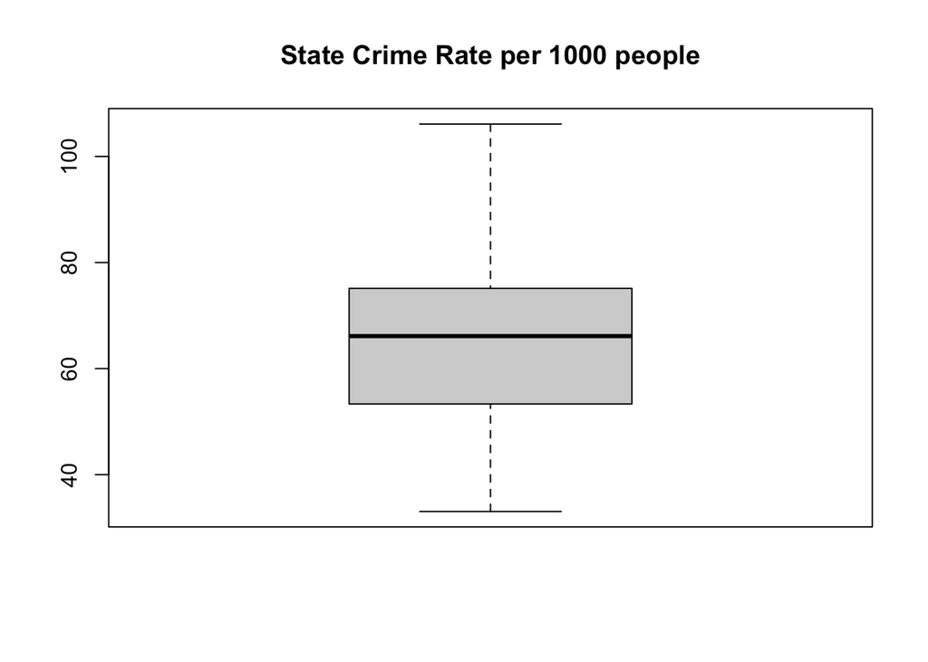

```r
boxplot(cdi_by_state$state_CRM_1000, main = 'State Crime Rate per 1000 people')
```